# NSS results

This is a notebook to analyse NNS data from 2014-2023, baswed on data from NSS wesbite.

If you don’t have eyethinkdata tools, install from github

```r
devtools::install_github("dcr-eyethink/eyethinkdata")
```

Load in the package and the raw data. Note that this has been filtered to just psychology courses, and students on first degree only.

```r
library(eyethinkdata)
full_data <- fread("NSS_2014-23.csv")
qkey <-  data.table(read.csv("qkey3.csv"))
```

First we need to translate the question numbers into the items and labels. There are 3 slightly difference question sets. Annoying. So we have to merge info from the question keys to three different sections. For each, we will have columns for the theme, the full question, and a one word question key q.

```r
d <- rbind( pid_merge(full_data[year<=2016], qkey[,.(QuestionNumber=qnum,theme=theme2014,q=item2014,question=set_full2014)],link="QuestionNumber"),
 pid_merge(full_data[year>2016 & year<2023], qkey[,.(QuestionNumber=qnum,theme=theme2017,q=item2017, question=set_full2017)],link="QuestionNumber"),
 pid_merge(full_data[year==2023], qkey[,.(QuestionNumber=qnum,theme=theme2023,q=item2023, question=set_full2023)],link="QuestionNumber"))
d
```

| year | UKPRN | Institution | cah | Subject | Level | QuestionNumber | A1 | A2 | A3 | A4 | A5 | N/A | Confidence interval - min | Actual value | Confidence interval - max | Response | Sample Size | Positivity measure (%) | Benchmark (%) | Difference (ppt) | Standard deviation | Contribution to benchmark (%) | Materially below benchmark (%) | Broadly in line with benchmark (%) | Materially above benchmark (%) | Publication response headcount | Publication response rate (%) | theme | q | … |
| --- | --- | --- | --- | --- | --- | --- | --- | --- | --- | --- | --- | --- | --- | --- | --- | --- | --- | --- | --- | --- | --- | --- | --- | --- | --- | --- | --- | --- | --- | --- |
| 2014 | 10000291 | Anglia Ruskin University |  | (07) Psychology | First degree | Q01 | 2% | 1% | 1% | 66% | 28% | 0 | 89% | 95% | 98% | 134 | 197 | NA | NA | NA | NA | NA | NA | NA | NA | NA | NA | teaching | explain | … |
| 2014 | 10000291 | Anglia Ruskin University |  | (07) Psychology | First degree | Q02 | 1% | 5% | 8% | 54% | 32% | 0 | 78% | 86% | 91% | 134 | 197 | NA | NA | NA | NA | NA | NA | NA | NA | NA | NA | teaching | interest | … |
| 2014 | 10000291 | Anglia Ruskin University |  | (07) Psychology | First degree | Q03 | 2% | 1% | 4% | 46% | 46% | 0 | 85% | 92% | 96% | 134 | 197 | NA | NA | NA | NA | NA | NA | NA | NA | NA | NA | teaching | enthusiastic | … |
| 2014 | 10000291 | Anglia Ruskin University |  | (07) Psychology | First degree | Q04 | 2% | 2% | 5% | 47% | 43% | 0 | 83% | 90% | 95% | 134 | 197 | NA | NA | NA | NA | NA | NA | NA | NA | NA | NA | teaching | stimulating | … |
| 2014 | 10000291 | Anglia Ruskin University |  | (07) Psychology | First degree | Q05 | 4% | 13% | 11% | 47% | 25% | 0 | 63% | 72% | 79% | 134 | 197 | NA | NA | NA | NA | NA | NA | NA | NA | NA | NA | assessment | clear | … |
| 2014 | 10000291 | Anglia Ruskin University |  | (07) Psychology | First degree | Q06 | 4% | 7% | 15% | 50% | 24% | 0 | 65% | 74% | 81% | 134 | 197 | NA | NA | NA | NA | NA | NA | NA | NA | NA | NA | assessment | fair | … |
| 2014 | 10000291 | Anglia Ruskin University |  | (07) Psychology | First degree | Q07 | 5% | 16% | 13% | 41% | 25% | 0 | 56% | 66% | 74% | 134 | 197 | NA | NA | NA | NA | NA | NA | NA | NA | NA | NA | assessment | timely | … |
| 2014 | 10000291 | Anglia Ruskin University |  | (07) Psychology | First degree | Q08 | 9% | 22% | 13% | 36% | 19% | 0 | 46% | 55% | 64% | 134 | 197 | NA | NA | NA | NA | NA | NA | NA | NA | NA | NA | assessment | detailed | … |
| 2014 | 10000291 | Anglia Ruskin University |  | (07) Psychology | First degree | Q09 | 8% | 24% | 18% | 37% | 13% | 1 | 40% | 50% | 59% | 133 | 197 | NA | NA | NA | NA | NA | NA | NA | NA | NA | NA | assessment | helpful | … |
| 2014 | 10000291 | Anglia Ruskin University |  | (07) Psychology | First degree | Q10 | 4% | 12% | 8% | 46% | 30% | 0 | 67% | 75% | 82% | 134 | 197 | NA | NA | NA | NA | NA | NA | NA | NA | NA | NA | academic | support | … |

[output cut: 990 more lines]

```r
NA
```

Now we want one number that summarises responses to the question. Right now we have the distribution of responses for each. All the items are framed positively, ie if they agree with the statement the student is saying something good about the university. So we’re going to code into a response variable between -1 and 1 that is positive if they are agreeing, and negative if they are disagreeing. This is different to how the NSS processes this. They have a positivity score, which I assume just calculates the % of responses that are agreeing in anyway. That seems to ignore some of the graded information we have in this dataset tbough.

For pre 2023, each question has 5 columns giving % responses for the 5 options from strongly agree to strongly disagree. Convert these first to numbers, and then sum to a -1 to 1 scale in a variable r.

```r
d[year<2023,ans_sd:=ifelse(A1=="",0,as.numeric(gsub(A1,replacement = "",pattern="%")))]
d[year<2023,ans_d:=ifelse(A2=="",0,as.numeric(gsub(A2,replacement = "",pattern="%")))]
d[year<2023,ans_n:=ifelse(A3=="",0,as.numeric(gsub(A3,replacement = "",pattern="%")))]
d[year<2023,ans_a:=ifelse(A4=="",0,as.numeric(gsub(A4,replacement = "",pattern="%")))]
d[year<2023,ans_sa:=ifelse(A5=="",0,as.numeric(gsub(A5,replacement = "",pattern="%")))]
d[year<2023,r:= (ans_sa + ans_a*.5  + ans_d *-.5 + ans_sd*-1)/100]
```

For 2023 onwards, We have total number of responses for 4 options from strongly agree to strongly disagree, ie there is no ‘neither agree nor disagree’ option. Convert these to a -1 to 1 scale as above.

```r
d[year>=2023,ans_sa:=ifelse(A1=="",0,as.numeric(A1))]
d[year>=2023,ans_a:=ifelse(A2=="",0,as.numeric(A2))]
d[year>=2023,ans_d:=ifelse(A3=="",0,as.numeric(A3))]
d[year>=2023,ans_sd:=ifelse(A4=="",0,as.numeric(A4))]
d[year>=2023,r:= (ans_sa + ans_a*.5  + ans_d *-.5 + ans_sd*-1)/(ans_sa+ans_a+ans_d+ans_sd)]
```

I’m going to exclude the questions that aren’t in the main list, and that are about the student union. Then let’s check the distribution of those values over all questions for each year.

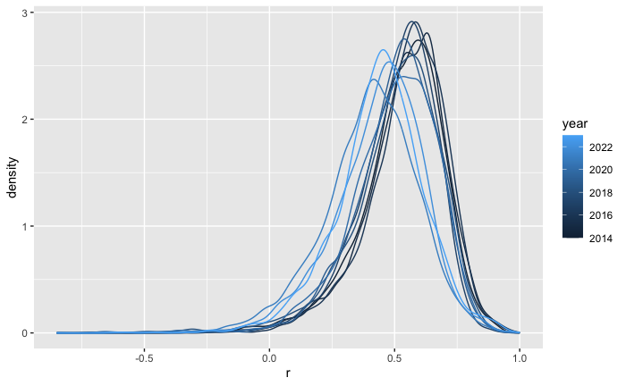

```r
d <- d[!theme=="union" & !is.na(theme)]
ggplot(d,aes(x=r,colour=year,group=year))+geom_density()
```

So it broadly looks as though agreement in these statement overall peaks around the positive, “agree” response, but that over the years, responses have been slipping down for everyone.

Now let’s plot UCL’s last 10 years for each theme There are vertical gray bars here to denote when questionnaire changed, making comparisons difficult. I am going to exclude the themes for mental_health, personal, overall satisfaction and freedom as they only have single question each that were only asked in a handful of years.

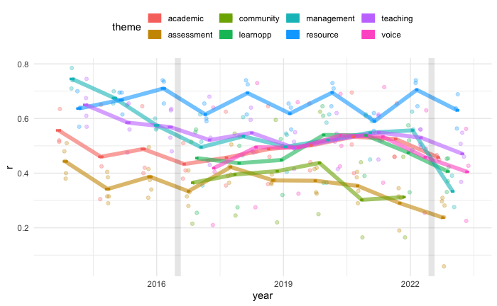

```r
d[,tm:=ifelse(theme %in% c("mental_health", "personal", "freedom","overall"),FALSE,TRUE)]
# this is a plot element with the new questionnaires marked. We can reuse it
yp <-  geom_vline(data=data.table(year=c(2016.5,2022.5)),alpha=0.1,linewidth=3,aes(xintercept=year))
pirateye(d[Institution=="University College London" & tm],x_condition = "year",
         colour_condition = "theme",line = T,dv="r",violin = F,error_bars = F)+yp
```

```r
NA
NA
```

So people love our resources! The rankings seem pretty stable over time here. Rankings seem higher pre 2017 and there is a drop off in 2023, but as the grey lines show, these changes are confounded by a different set of questions (and responses). What does seem clear here is that our weak point is our assessments. These are ranked low and if anything have been getting worse.

How do we match up with the average psych dept? Here’s all rankings over the years, comparing UCL against all other psych depts.

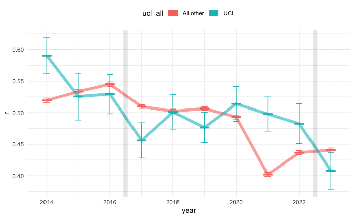

```r
d[,ucl:=ifelse(Institution=="University College London",TRUE,FALSE)]
d[,ucl_all:=ifelse(Institution=="University College London","UCL","All other")]
pirateye(d[ (tm) ],x_condition = "year",colour="ucl_all",dodgewidth = 0,
         line = T,dv="r",violin = F,error_bars = T,dots=F)+yp
```

So in general terms: we had a relatively great pandemic! At least up until 2023 (the cohort that were in their first year during pandemic). But again the picture is complicated by the change in survey. We can split those responses by theme and compare against other depts. It’s a bit messy comparing all individual themes for both, so let’s try and simplify this by using a baseline. We can z score the r values for each question, each year.

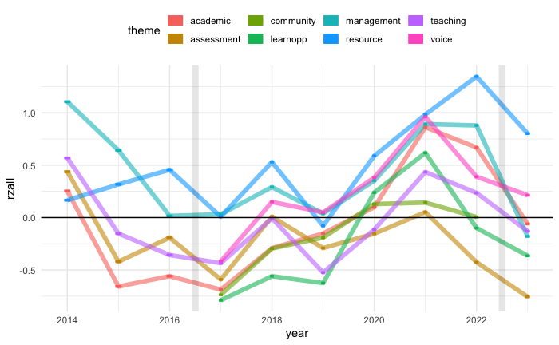

```r
d[, rzall:=scale(r),by=.(year,question)]
pirateye( d[ucl & tm],x_condition = "year",colour_condition =  "theme",dodgewidth = 0,
         line = T,dv="rzall",violin = F,error_bars = F,dots=F)+yp+geom_hline(aes(yintercept=0))
```

So now the psychology sector average for each year is 0, shown by heavy black line. Benchmarked like this, it looks like we had a good period of growth from 2016 onwards, and in the pandemic years we were well above the mean in almost everything. But again, our assessments are ranked below the mean and perhaps trending down